# SDI trends in Latin America

# Survey Presentation

**Survey about the adoption of technological trends in the context of Spatial Data Infraestructures in Latin America**

- Instituto Politecnico Nacional, Ciudad de Mexico (Mexico) - Luis M. Vilches-Blazquez - `lmvilches@cic.ipn.mx`
- Universidad del Azuay, Cuenca (Ecuador) - Daniela Ballari - `dballari@uazuay.edu.ec`

**Objective**

Identify, within Latin America context, the development state of Spatial Data Infrastructures (SDI) applications that integrate technological trends, such as: mobile devices, sensors, cloud computing, volunteer geographical information, augmented reality, semantic web, big data, and Internet Of Things (IoT), among others.

**Addressed to**

Public institutions, private enterprises, freelance professionals, universities, and research centers, that are related to professional and scientific SDI work within Latin America.

**Topics**

1- Trends adoption

2- Standardization

3- Monitoring & Reporting

4- Future vision & limitations

**Dates**

The survey was performed three times: 2014, 2017 and 2018/2019.

**How to cite this work**

Vilches-Blazquez, L. & Ballari, D. Unveiling the diversity of geospatial IT trends in Latin America. Evidence from its Spatial Data Infrastructure community. Submitted.

# Part 0. Overall survey data

## Number of responses per year

- 2019: 88 responses
- 2017: 51 responses
- 2014: 32 responses

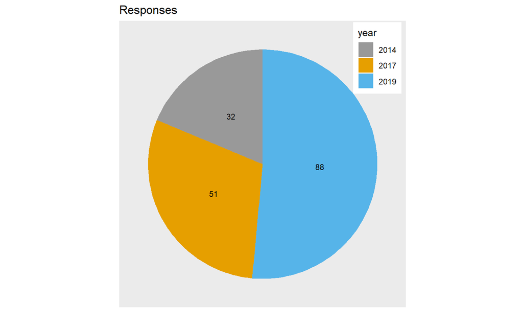

## Type of institution

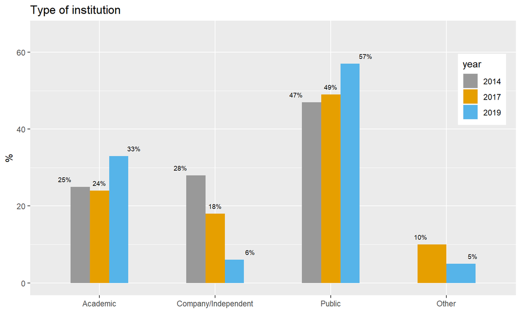

## Country representation

- 2019: 19 countries.
- 2017: 13 countries.
- 2014: 10 countries.

### Figure

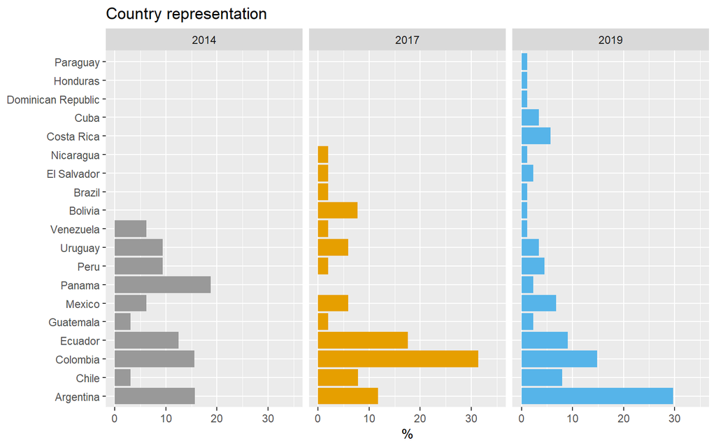

### Maps

Category of 1 means that the country only participated in one survey, 2 in 2 of them, an 3 in the three of them.

[output not shown]

[output not shown]

[output not shown]

[output not shown]

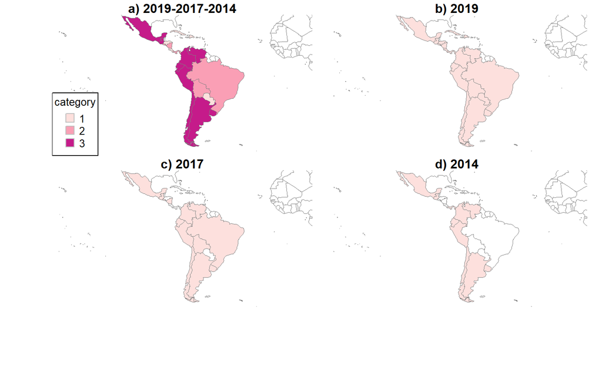

# Part 1. Trend adoption

## Trend implementation

Q. Have you or your institution developed (or are developing) applications or services related to SDI that integrate IT trends? Remember that among the new trends, for example, are: mobile devices, sensors, cloud computing, voluntary geo-information, augmented reality, semantic web, big data, internet of things, among others.

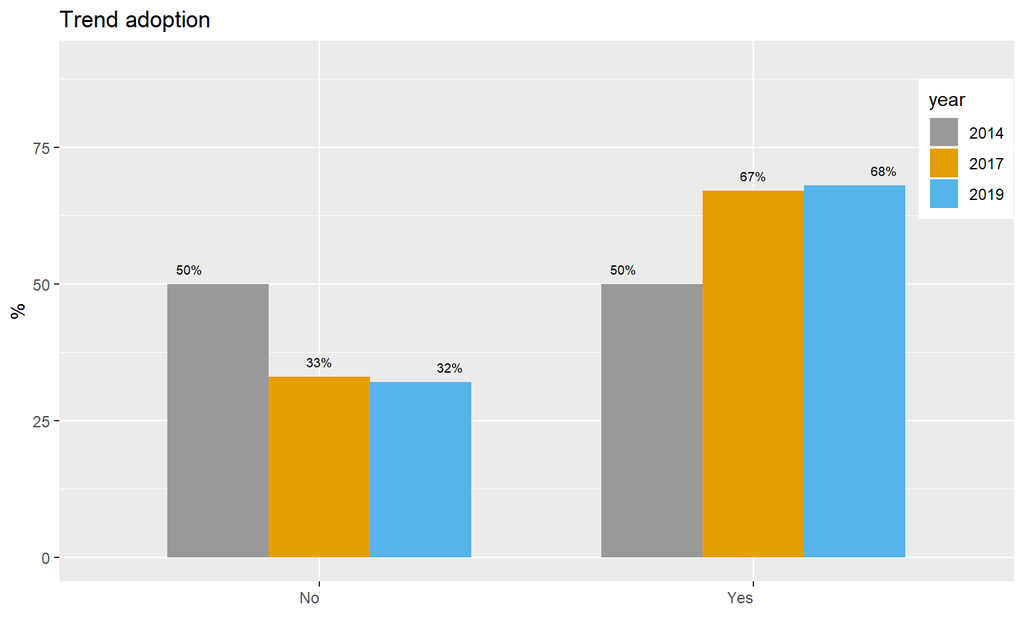

## Trend adoption by country

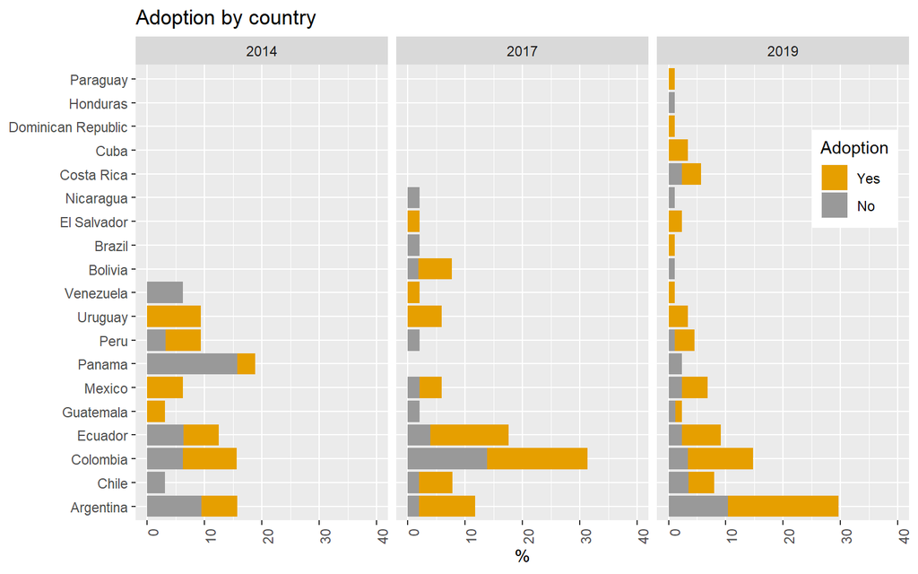

## Trend details

Q. Mark the innovative trends you have implemented / related to Spatial Data Infrastructures.

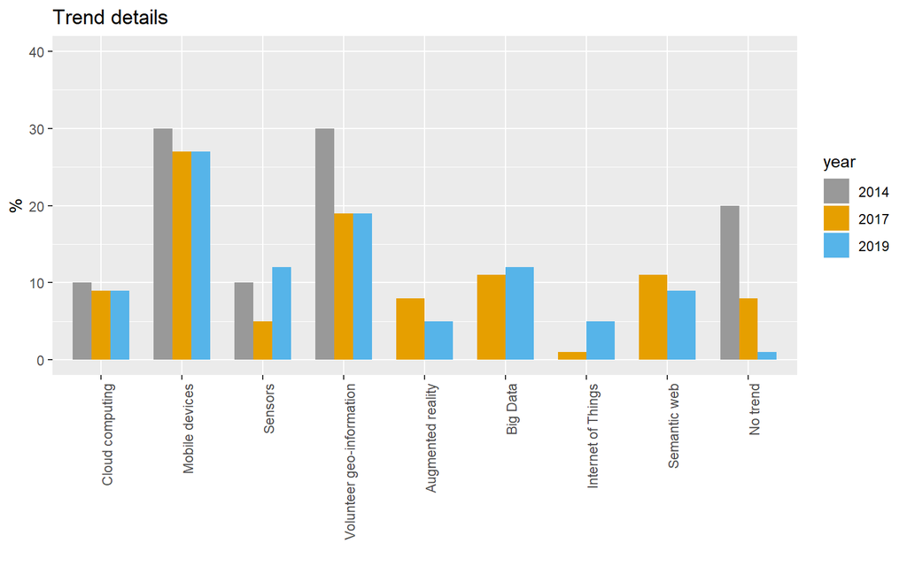

## SDI Age

Q. How many years does your SDI initiative have?

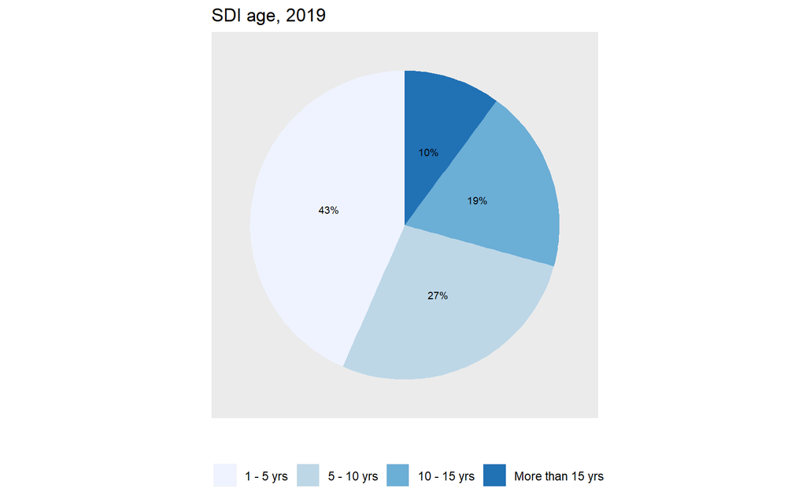

## Trend adoption by age

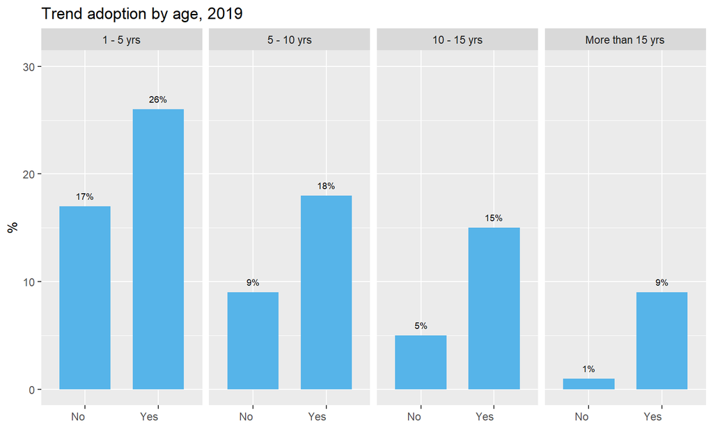

## Maturity

Q. In what state of development do you perceive SDI are in your country, region or city?

### Figure

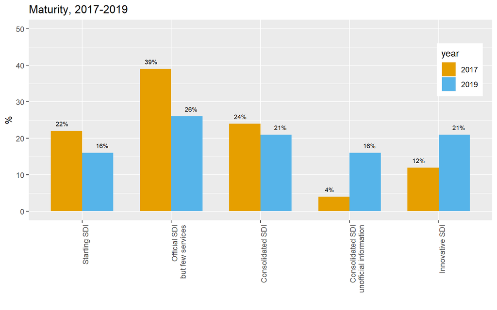

### Categories

[output not shown]

# Part 2. Standarization

## Implementation with specifications

Q. Have you made the development of the new trends in your SDI following standards and specifications?

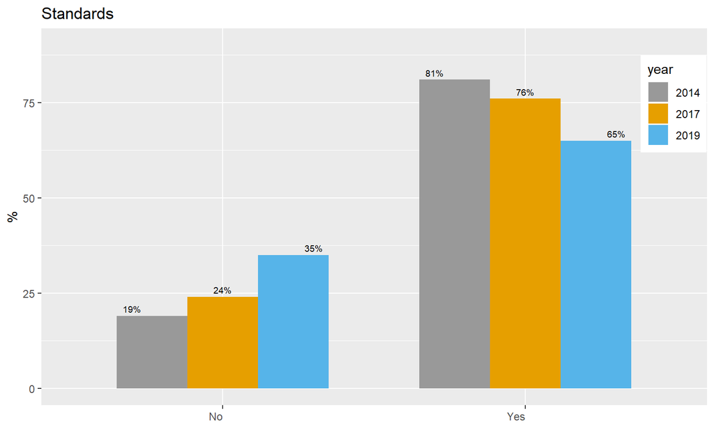

## Standarization organisms

Q. Detail to what organism belong the used standards and specifications

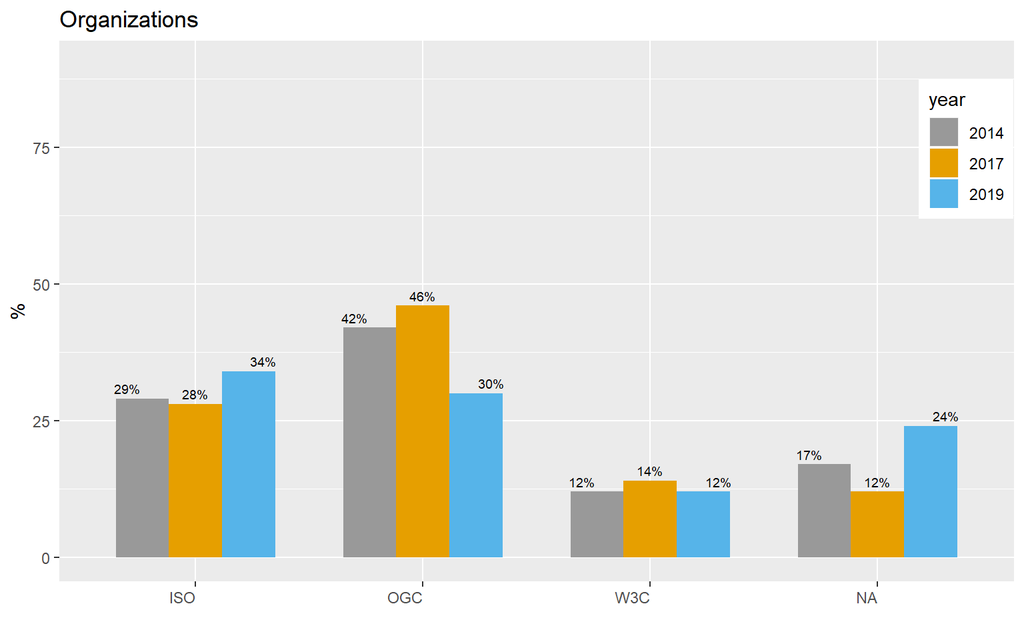

## Details of the used specifications

Q. Detail the used standards and specifications

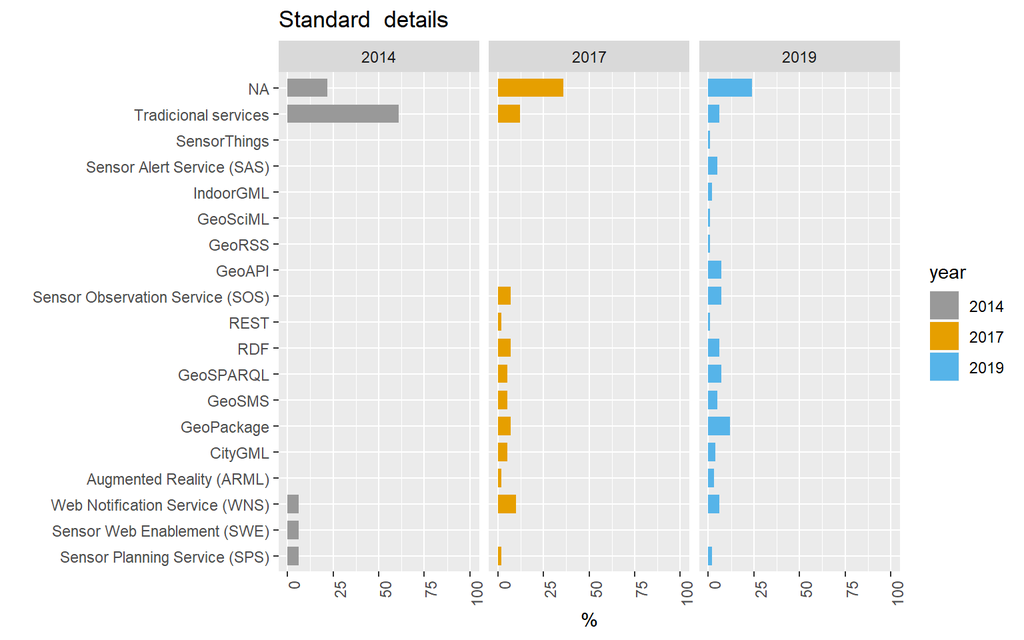

## Limitations of specifications

Q. Have you identified any aspect of SDI, data or services that need to be standardized with new standards and specifications and that are not yet available?

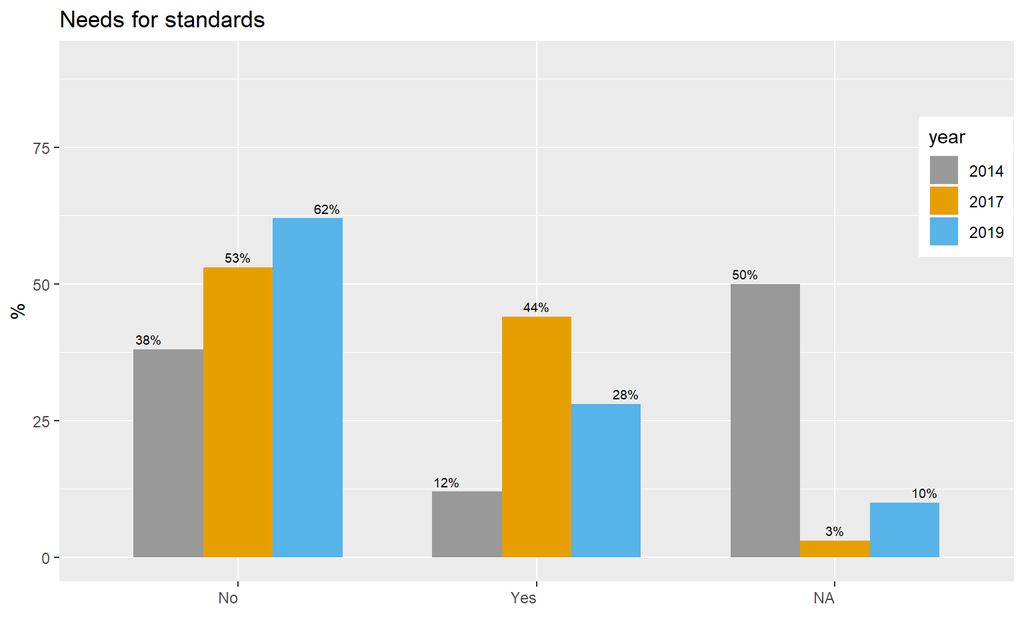

# Part 3. Monitoring and reporting

## Monitoring

Q. Do you monitor the use of the applications?

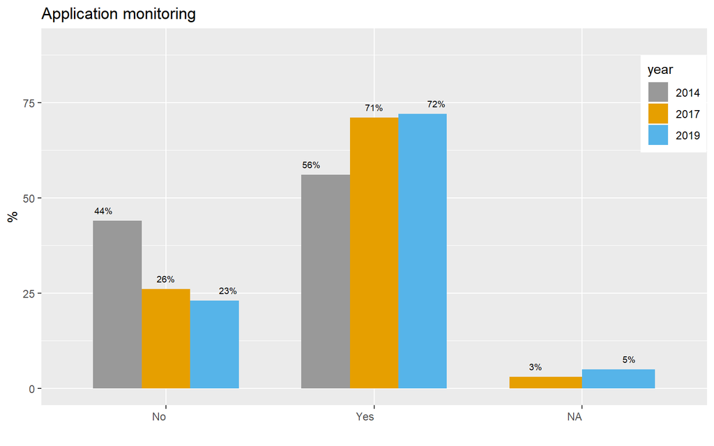

### Monitoring strategy

Q. How did you do the monitoring?

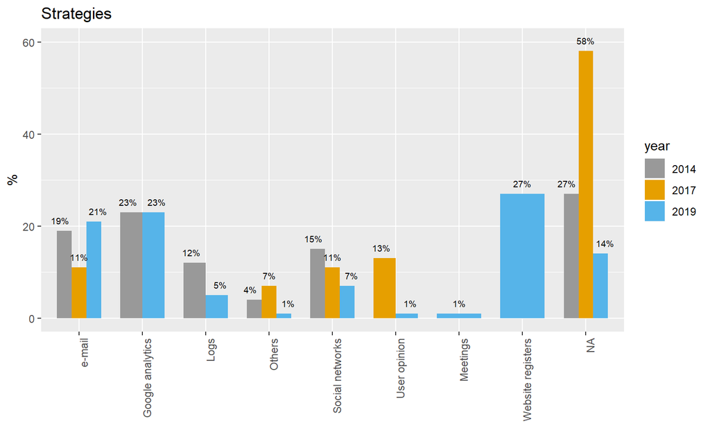

### Monitoring objective

Q. What has been the objective of the monitoring?

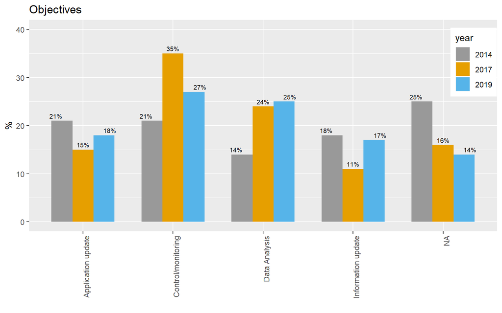

## Monitoring of Society impact

Q. Do you monitor the impact of the application on the society?

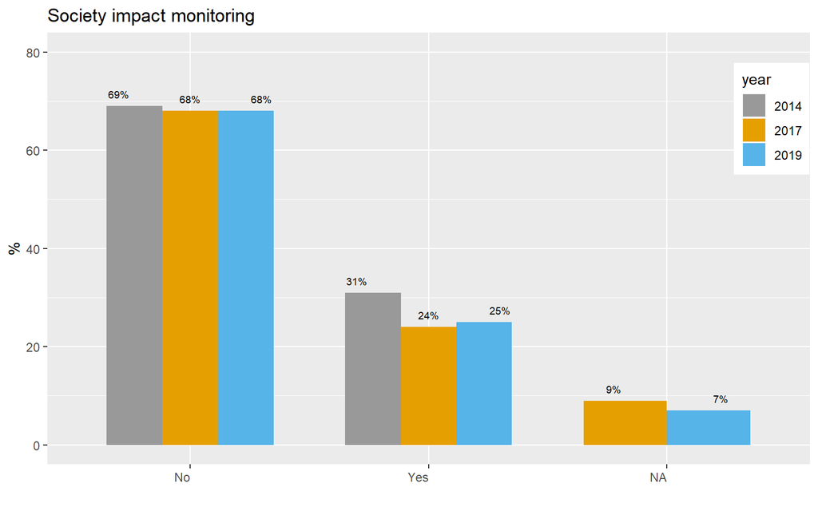

### Strategy

Q. How did you do the monitoring?

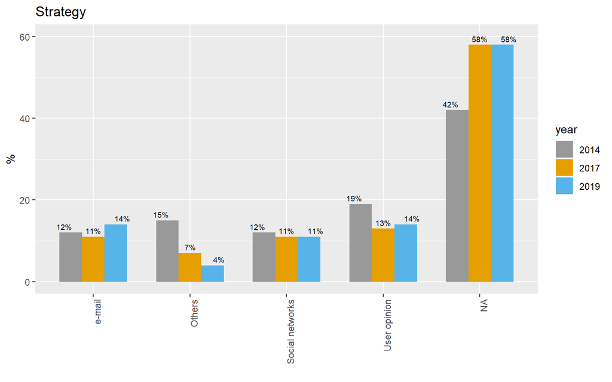

# Part 4.Future vision and limitations

## Future vision

Q. What is your vision of the SDI initiative of your country, region or city for the next 10 years?

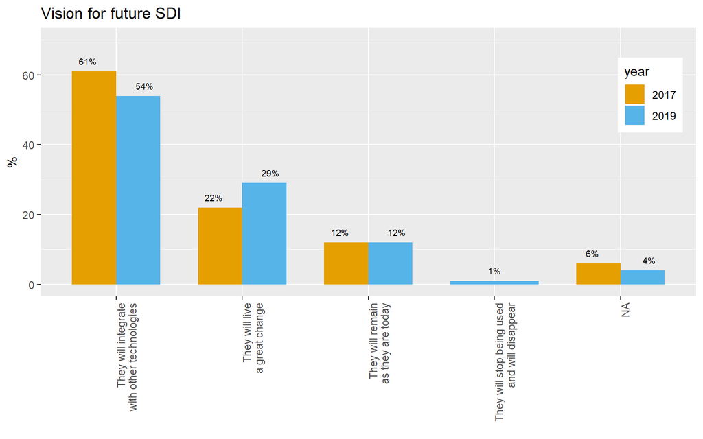

## Limitations

Q. What are the main limitations for the development of the SDI trends? Identify new trends such as: mobile devices, sensors, cloud computing, augmented reality, semantic web, big data, internet of the things, among others.

### Figure

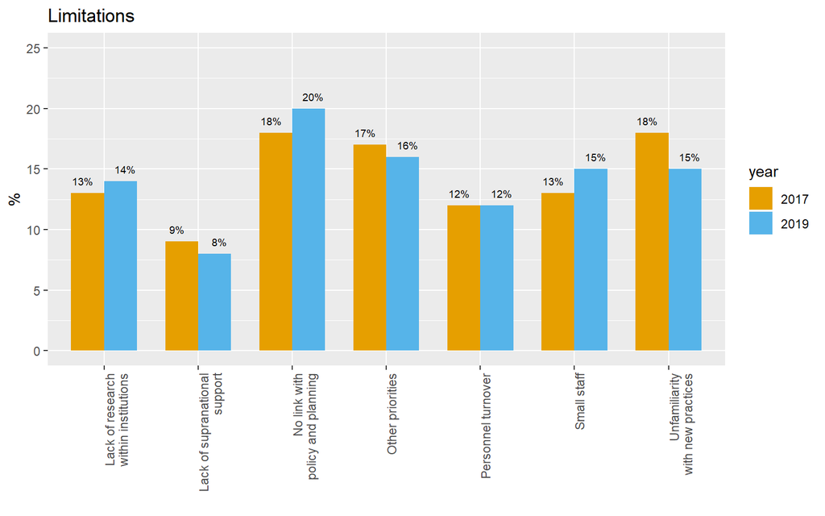

### Categories

| Category | Explanation |
| --- | --- |
| Other priorities | The existence of other institutional priorities |
| Small staff | Having a small dedicated staff |
| Unfamiliarity with new practices | Unfamiliarity with new practices, specifications and trends |
| No link with, policy and planning | Unlinking from SDIs from public policy development and planning |
| Lack of supranational support | Absence of a national / supranational organization that supports and accompanies the consolidation of IDE initiatives |
| Lack of research, within institutions | Absence of research processes within institutions |
| Personnel turnover | High turnover of personnel in institutions |

Daniela Ballari - Luis Vilches

2019-05-23